# Transfer Learning People Vs Horses

This project will use `Transfer Learning` to help classify on an image data set called hourses vs humans.

Let's get started!

```python
import os
import zipfile
import matplotlib.pyplot as plt
import tensorflow as tf
from tensorflow.keras import layers
from tensorflow.keras import Model
from tensorflow.keras.optimizers import RMSprop
from tensorflow.keras.preprocessing.image import ImageDataGenerator
from tensorflow.keras.utils import img_to_array, load_img
```

## Dataset

For this assignment, the `Horse or Human dataset` contains images of horses and humans.

Download the `training` and `validation` sets by running the cell below:

```python
# Get the Horse or Human training dataset
!wget -q -P /content/ https://storage.googleapis.com/tensorflow-1-public/course2/week3/horse-or-human.zip

# Get the Horse or Human validation dataset
!wget -q -P /content/ https://storage.googleapis.com/tensorflow-1-public/course2/week3/validation-horse-or-human.zip

test_local_zip = './horse-or-human.zip'
zip_ref = zipfile.ZipFile(test_local_zip, 'r')
zip_ref.extractall('/tmp/training')

val_local_zip = './validation-horse-or-human.zip'
zip_ref = zipfile.ZipFile(val_local_zip, 'r')
zip_ref.extractall('/tmp/validation')

zip_ref.close()
```

Save the paths of the images so you can use them later on:

```python
# grader-required-cell

# Define the training and validation base directories
train_dir = '/tmp/training'
validation_dir = '/tmp/validation'

# Directory with training horse pictures
train_horses_dir = os.path.join(train_dir, 'horses')
# Directory with training humans pictures
train_humans_dir = os.path.join(train_dir, 'humans')
# Directory with validation horse pictures
validation_horses_dir = os.path.join(validation_dir, 'horses')
# Directory with validation human pictures
validation_humans_dir = os.path.join(validation_dir, 'humans')

# Check the number of images for each class and set
print(f"There are {len(os.listdir(train_horses_dir))} images of horses for training.\n")
print(f"There are {len(os.listdir(train_humans_dir))} images of humans for training.\n")
print(f"There are {len(os.listdir(validation_horses_dir))} images of horses for validation.\n")
print(f"There are {len(os.listdir(validation_humans_dir))} images of humans for validation.\n")
```

```
There are 500 images of horses for training.

There are 527 images of humans for training.

There are 128 images of horses for validation.

There are 128 images of humans for validation.
```

Now take a look at a sample image of each one of the classes:

```
Sample horse image:
```

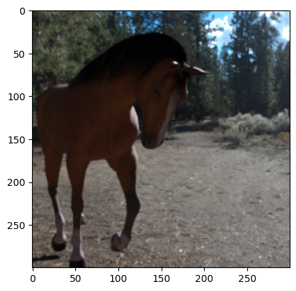

```
Sample human image:
```

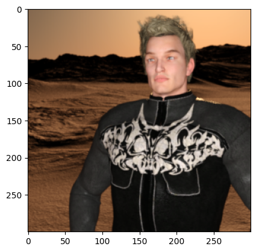

```python
print("Sample horse image:")
plt.imshow(load_img(f"{os.path.join(train_horses_dir, os.listdir(train_horses_dir)[0])}"))
plt.show()

print("\nSample human image:")
plt.imshow(load_img(f"{os.path.join(train_humans_dir, os.listdir(train_humans_dir)[0])}"))
plt.show()
```

```python
# Load the first example of a horse
sample_image  = load_img(f"{os.path.join(train_horses_dir, os.listdir(train_horses_dir)[0])}")

# Convert the image into its numpy array representation
sample_array = img_to_array(sample_image)

print(f"Each image has shape: {sample_array.shape}")
```

```
Each image has shape: (300, 300, 3)
```

As expected, the sample image has a resolution of 300x300 and the last dimension is used for each one of the RGB channels to represent color.

## Training and Validation Generators

**Important Note:** The images have a resolution of 300x300 but the `flow_from_directory` method allows to set a target resolution. In this case, **a `target_size` of (150, 150)** will be used. This will heavily lower the number of trainable parameters in the final network.

```python
def train_val_generators(TRAINING_DIR, VALIDATION_DIR):
  #Creates the training and validation data generators

  #Args:
    #TRAINING_DIR (string): directory path containing the training images
    #VALIDATION_DIR (string): directory path containing the testing/validation images

  #Returns:
    #train_generator, validation_generator: tuple containing the generators
  # Instantiate the ImageDataGenerator class, normalize pixels with rescale
  train_datagen = ImageDataGenerator(rescale = 1./255.,
                                   rotation_range = 40,
                                   width_shift_range = 0.2,
                                   height_shift_range = 0.2,
                                   shear_range = 0.2,
                                   zoom_range = 0.2,
                                   horizontal_flip = True)
  # Pass in the arguments to the flow_from_directory method
  train_generator = train_datagen.flow_from_directory(train_dir,
                                                    batch_size = 20,
                                                    class_mode = 'binary',
                                                    target_size = (150, 150))
 # Instantiate the ImageDataGenerator class, rescale pixels
  test_datagen = ImageDataGenerator( rescale = 1.0/255. )
# Pass in the arguments to the flow_from_directory method
  validation_generator =  test_datagen.flow_from_directory( validation_dir,
                                                          batch_size  = 20,
                                                          class_mode  = 'binary',
                                                          target_size = (150, 150))

  return train_generator, validation_generator
```

```python
# Test the generators
train_generator, validation_generator = train_val_generators(train_dir, validation_dir)
```

```
Found 1027 images belonging to 2 classes.
Found 256 images belonging to 2 classes.
```

## Transfer learning - Create the pre-trained model

Downloading the `inception V3` weights into the `/tmp/` directory:

```python
# Download the inception v3 weights
!wget --no-check-certificate \
    https://storage.googleapis.com/mledu-datasets/inception_v3_weights_tf_dim_ordering_tf_kernels_notop.h5 \
    -O /tmp/inception_v3_weights_tf_dim_ordering_tf_kernels_notop.h5
```

```
--2024-02-12 22:17:06--  https://storage.googleapis.com/mledu-datasets/inception_v3_weights_tf_dim_ordering_tf_kernels_notop.h5
Resolving storage.googleapis.com (storage.googleapis.com)... 173.194.79.207, 108.177.96.207, 108.177.119.207, ...
Connecting to storage.googleapis.com (storage.googleapis.com)|173.194.79.207|:443... connected.
HTTP request sent, awaiting response... 200 OK
Length: 87910968 (84M) [application/x-hdf]
Saving to: ‘/tmp/inception_v3_weights_tf_dim_ordering_tf_kernels_notop.h5’

/tmp/inception_v3_w 100%[===================>]  83.84M  26.5MB/s    in 3.2s

2024-02-12 22:17:09 (26.5 MB/s) - ‘/tmp/inception_v3_weights_tf_dim_ordering_tf_kernels_notop.h5’ saved [87910968/87910968]
```

Now load the `InceptionV3` model and save the path to the weights:

```python
# Import the inception model
from tensorflow.keras.applications.inception_v3 import InceptionV3

# Create an instance of the inception model from the local pre-trained weights
local_weights_file = '/tmp/inception_v3_weights_tf_dim_ordering_tf_kernels_notop.h5'
```

Complete the `create_pre_trained_model` function below and make all of the layers non-trainable:

```python
def create_pre_trained_model(local_weights_file):
  #Initializes an InceptionV3 model.

  #Args:
   # local_weights_file (string): path pointing to a pretrained weights H5 file

  #Returns:
    #pre_trained_model: the initialized InceptionV3 model
  pre_trained_model = InceptionV3(input_shape = (150, 150, 3),
                                  include_top = False,
                                  weights = None)

  pre_trained_model.load_weights(local_weights_file)

  # Make all the layers in the pre-trained model non-trainable
  for layer in pre_trained_model.layers:
    layer.trainable = False
  return pre_trained_model
```

```python
pre_trained_model = create_pre_trained_model(local_weights_file)
```

To check that all the layers in the model were set to be non-trainable, you can also run the cell below:

```python
total_params = pre_trained_model.count_params()
num_trainable_params = sum([w.shape.num_elements() for w in pre_trained_model.trainable_weights])

print(f"There are {total_params:,} total parameters in this model.")
print(f"There are {num_trainable_params:,} trainable parameters in this model.")
```

[output not shown]

## Creating callbacks for later

```python
# Defines a Callback class that stops training once accuracy reaches 99.9%
class myCallback(tf.keras.callbacks.Callback):
  def on_epoch_end(self, epoch, logs={}):
    if(logs.get('accuracy')>0.999):
      print("\nReached 99.9% accuracy so cancelling training!")
      self.model.stop_training = True
```

## Pipelining the pre-trained model

After some investigating I will add on to the pre-trained model after layers `mixed7`

```python
def output_of_last_layer(pre_trained_model):
  #Gets the last layer output of a model

  #Args:
    #pre_trained_model (tf.keras Model): model to get the last layer output from

  #Returns:
    #last_output: output of the model's last layer
  last_desired_layer = pre_trained_model.get_layer('mixed7')
  print('last layer output shape: ', last_desired_layer.output_shape)
  last_output = last_desired_layer.output
  print('last layer output: ', last_output)


  return last_output
```

```python
last_output = output_of_last_layer(pre_trained_model)
```

```
last layer output shape:  (None, 7, 7, 768)
last layer output:  KerasTensor(type_spec=TensorSpec(shape=(None, 7, 7, 768), dtype=tf.float32, name=None), name='mixed7/concat:0', description="created by layer 'mixed7'")
```

Looks good!

I will create the final model by adding some additional layers on top of the pre-trained model.

```python
print(f"The pretrained model has type: {type(pre_trained_model)}")
```

```
The pretrained model has type: <class 'keras.src.engine.functional.Functional'>
```

```python
def create_final_model(pre_trained_model, last_output):
  #Appends a custom model to a pre-trained model

  #Args:
    #pre_trained_model (tf.keras Model): model that will accept the train/test inputs
    #last_output (tensor): last layer output of the pre-trained model

  #Returns:
    #model: the combined model
  # Flatten the output layer to 1 dimension
  x = layers.Flatten()(last_output)
 # Add a fully connected layer with 1024 hidden units and ReLU activation
  x = layers.Dense(1024, activation='relu')(x)
  # Add a dropout rate of 0.2
  x = layers.Dropout(.2)(x)
  # Add a final sigmoid layer for classification
  x = layers.Dense(1, activation = 'sigmoid')(x)

  # Create the complete model by using the Model class
  model = Model(inputs= pre_trained_model.input, outputs=x)

  # Compile the model
  model.compile(optimizer = RMSprop(learning_rate=0.0001),
                loss = 'binary_crossentropy',
                metrics = ['accuracy'])
  return model
```

```python
# Save model in a variable
model = create_final_model(pre_trained_model, last_output)

# Inspect parameters
total_params = model.count_params()
num_trainable_params = sum([w.shape.num_elements() for w in model.trainable_weights])

print(f"There are {total_params:,} total parameters in this model.")
print(f"There are {num_trainable_params:,} trainable parameters in this model.")
```

```
There are 47,512,481 total parameters in this model.
There are 38,537,217 trainable parameters in this model.
```

```python
# Run this and see how many epochs it should take before the callback
# fires, and stops training at 99.9% accuracy
callbacks = myCallback()
history = model.fit(train_generator,
                    validation_data = validation_generator,
                    epochs = 100,
                    verbose = 2,
                    callbacks=callbacks)
```

```
52/52 - 26s - loss: 0.1726 - accuracy: 0.9416 - val_loss: 0.0344 - val_accuracy: 0.9883 - 26s/epoch - 502ms/step
52/52 - 12s - loss: 0.0305 - accuracy: 0.9873 - val_loss: 0.0142 - val_accuracy: 0.9961 - 12s/epoch - 239ms/step
52/52 - 12s - loss: 0.0236 - accuracy: 0.9951 - val_loss: 0.0013 - val_accuracy: 1.0000 - 12s/epoch - 239ms/step
52/52 - 12s - loss: 0.0168 - accuracy: 0.9912 - val_loss: 0.0084 - val_accuracy: 0.9961 - 12s/epoch - 235ms/step
52/52 - 12s - loss: 0.0101 - accuracy: 0.9961 - val_loss: 0.0622 - val_accuracy: 0.9805 - 12s/epoch - 239ms/step
52/52 - 12s - loss: 0.0144 - accuracy: 0.9951 - val_loss: 0.0445 - val_accuracy: 0.9805 - 12s/epoch - 235ms/step
52/52 - 12s - loss: 0.0108 - accuracy: 0.9951 - val_loss: 3.8800e-04 - val_accuracy: 1.0000 - 12s/epoch - 240ms/step
52/52 - 12s - loss: 0.0072 - accuracy: 0.9971 - val_loss: 0.0200 - val_accuracy: 0.9922 - 12s/epoch - 238ms/step
52/52 - 12s - loss: 0.0107 - accuracy: 0.9971 - val_loss: 8.1087e-04 - val_accuracy: 1.0000 - 12s/epoch - 235ms/step
52/52 - 12s - loss: 0.0092 - accuracy: 0.9951 - val_loss: 0.0076 - val_accuracy: 0.9961 - 12s/epoch - 240ms/step

Reached 99.9% accuracy so cancelling training!
52/52 - 12s - loss: 0.0010 - accuracy: 1.0000 - val_loss: 0.0070 - val_accuracy: 0.9961 - 12s/epoch - 235ms/step
```

Now take a quick look at the training and validation accuracies for each epoch of training:

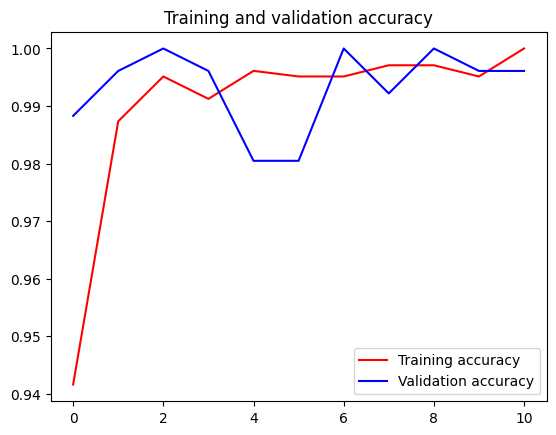

```python
# Plot the training and validation accuracies for each epoch

acc = history.history['accuracy']
val_acc = history.history['val_accuracy']
loss = history.history['loss']
val_loss = history.history['val_loss']

epochs = range(len(acc))

plt.plot(epochs, acc, 'r', label='Training accuracy')
plt.plot(epochs, val_acc, 'b', label='Validation accuracy')
plt.title('Training and validation accuracy')
plt.legend(loc=0)
plt.figure()

plt.show()
```